# Practical L

Gerko Vink

Statistical Programming in R

We use the following packages:

```r
library(mice)
```

```r
library(magrittr)
library(ggplot2movies)
```

1. **Use the `brandsma` data from package `mice` to fit a logistic regression model for `sex` based on `lpo` (Language Post Outcome).**

```r
fit <-
  brandsma %$%
  glm(sex ~ lpo, family=binomial(link='logit'))
```

2. **Inspect the model parameters. What do you conclude?**

```r
summary(fit)
```

```
##
## Call:
## glm(formula = sex ~ lpo, family = binomial(link = "logit"))
##
## Deviance Residuals:
##    Min      1Q  Median      3Q     Max
## -1.371  -1.152  -0.909   1.165   1.626
##
## Coefficients:
##              Estimate Std. Error z value Pr(>|z|)
## (Intercept) -1.279636   0.156570  -8.173 3.01e-16 ***
## lpo          0.029727   0.003694   8.047 8.50e-16 ***
## ---
## Signif. codes:  0 '***' 0.001 '**' 0.01 '*' 0.05 '.' 0.1 ' ' 1
##
## (Dispersion parameter for binomial family taken to be 1)
##
##     Null deviance: 5395.9  on 3893  degrees of freedom
## Residual deviance: 5329.5  on 3892  degrees of freedom
##   (212 observations deleted due to missingness)
## AIC: 5333.5
##
## Number of Fisher Scoring iterations: 4
```

With every unit increase in `lpo`, the logodds of gender increases by 0.0297266.

3. **Obtain confidence intervals for the parameter estimates**

```r
confint(fit)
```

```
##                  2.5 %      97.5 %
## (Intercept) -1.5879389 -0.97404439
## lpo          0.0225129  0.03699717
```

The dataset `movies` contains data from imdb.com, a website that collects information about movies and allows users to rate these. It’s in the `ggplot2movies` package, so if you do not have it, install that package first using `install.packages("ggplot2movies")`, then load the package.

6. **The dataset is quite large, so it might be sluggish to work with. Create a new dataset that only has movies released after 2000 to speed up our other analyses. Also, we are interested in feature films, so throw away all movies shorter than 50 minutes and throw out all movies longer than 300 minutes. Use `range` to check that the new dataset is correct. We will work with this dataset from now on.**

```r
mv <- subset(movies, year > 2000 & length > 50 & length < 300)
range(mv$length)
```

```
## [1]  51 278
```

```r
range(mv$year)
```

```
## [1] 2001 2005
```

7. **What movie has the most votes?**

```r
# which.max returns the index number of the highest number of votes.
mv[which.max(mv$votes), "title"]
```

```
## # A tibble: 1 x 1
##   title
##   <chr>
## 1 Lord of the Rings: The Fellowship of the Ring, The
```

```r
# By sorting on the number of votes we can obtain the top 10.
tail(mv[order(mv$votes), c("title", "votes")], n=10)
```

```
## # A tibble: 10 x 2
##    title                                                   votes
##    <chr>                                                   <int>
##  1 Donnie Darko                                            51961
##  2 Matrix Reloaded, The                                    57225
##  3 Pirates of the Caribbean: The Curse of the Black Pearl  60812
##  4 Spider-Man                                              63228
##  5 Star Wars: Episode II - Attack of the Clones            63889
##  6 Kill Bill: Vol. 1                                       65026
##  7 Shrek                                                   65146
##  8 Lord of the Rings: The Return of the King, The         103631
##  9 Lord of the Rings: The Two Towers, The                 114797
## 10 Lord of the Rings: The Fellowship of the Ring, The     157608
```

8. **Add the logarithm of the budget to the dataset. Change the `-Inf` values (use `is.infinite()` to `NA`.**

```r
mv$logbudget <- log(mv$budget)
mv$logbudget[is.infinite(mv$logbudget)] <- NA
```

9. **Does a having a bigger budget mean a higher or a lower rating on IMDB? Perform tests and make plots. You can also test and plot using the logarithm of the budget.**

```r
# Using the budget directly.
cor(mv$budget, mv$rating, use = "complete.obs")
```

```
## [1] 0.01866161
```

```r
cor.test(mv$budget, mv$rating, use = "complete.obs")
```

```
##
##  Pearson's product-moment correlation
##
## data:  mv$budget and mv$rating
## t = 0.66333, df = 1263, p-value = 0.5072
## alternative hypothesis: true correlation is not equal to 0
## 95 percent confidence interval:
##  -0.03649197  0.07370186
## sample estimates:
##        cor
## 0.01866161
```

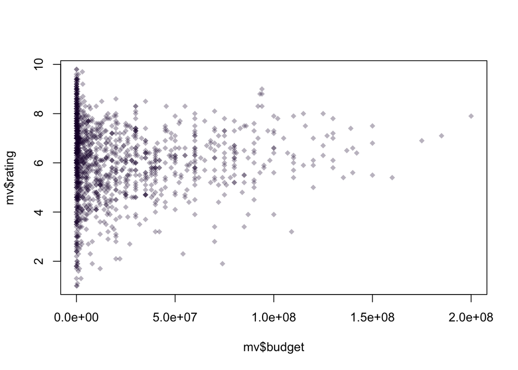

```r
plot(mv$budget, mv$rating, col = rgb(.1, 0, .2, .3), pch=18)
```

```r
# Using the logarithm.
cor(mv$logbudget, mv$rating, use = "complete.obs")
```

```
## [1] -0.1270749
```

```r
cor.test(mv$logbudget, mv$rating, use = "complete.obs")
```

```
##
##  Pearson's product-moment correlation
##
## data:  mv$logbudget and mv$rating
## t = -4.5458, df = 1259, p-value = 6e-06
## alternative hypothesis: true correlation is not equal to 0
## 95 percent confidence interval:
##  -0.18100859 -0.07237925
## sample estimates:
##        cor
## -0.1270749
```

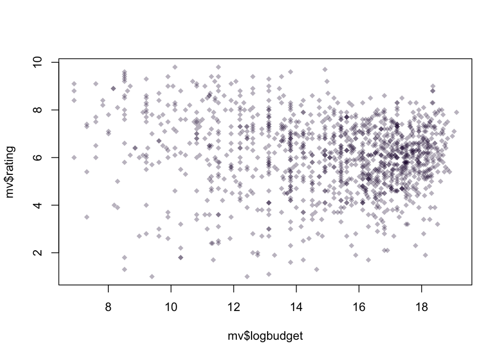

```r
plot(mv$logbudget, mv$rating, col = rgb(.1, 0, .2, .3), pch=18)
```

10. **Are drama’s generally longer than animated films? Perform tests and make plots, for example `density` plots.**

```r
# Separate the two genres. Note: they are not mutually exclusive.
drama.mv <- mv[mv$Drama==1 & mv$Animation != 1, ]
anim.mv  <- mv[mv$Animation==1 & mv$Drama != 1, ]

# Test whether they differ.
t.test(drama.mv$length, anim.mv$length)
```

```
##
##  Welch Two Sample t-test
##
## data:  drama.mv$length and anim.mv$length
## t = 14.771, df = 112.25, p-value < 2.2e-16
## alternative hypothesis: true difference in means is not equal to 0
## 95 percent confidence interval:
##  16.20760 21.22909
## sample estimates:
## mean of x mean of y
## 102.32251  83.60417
```